# flutter

Flutter is an open-source UI software devellopment kit (SDK) created by Google.

Its main goal is to allow developers to build natively compiled applications for multiple platforms from a single codebase.

And Dart is the programming language that Flutter uses to write those applications. It is the engine that runs the logic behind the Flutter UI.

```
raw
```

Flutter relies on a declarative UI paradigm, that is:

- you simply describe what the UI should look like for a given state, and the framework automatically updates the screen when that state changes
- this is the opposite of imperative UI, in which you tell the system how to change the interface step by step.

In order to use Flutter, you have to import it:

```
import 'package:flutter/material.dart';
```

## Widgets

In Flutter, everything you see or interact with is a widget.

- Widgets are the fundamental building blocks of a Flutter application. Everything from a simple button or text to the entire screen layout, themes, and even gesture detection is a widget.
- You can think of widgets as the Lego Pieces: some display content (like text or images), while other control how things are arranges (like rows or columns)

```
raw
```

Every screen in Flutter is ultimately built as a widget tree:

- Eaach widget tells Flutter how it wants to be drawn and how it should layout its children.
- The framework recursively builds this widget tree.

```
MaterialApp
 └── Scaffold
      ├── AppBar
      └── Body (like Column, Row, etc.)
```

Widgets in Flutter can be categorized into two:

1. Stateles Widgets
2. Stateful Widgets

A **Stateless Widget** is immutable.

- Meaning that ince it's built, its configuration (properties) cannot change during the widget's lifetime unless the entir widget is replacced by its parent in the Widget Tree.
- Stateless widgets are ideal for static element whose appearance depends solely on the configuration data passed to them via their constructor- i.e., ideal for UI that doesn't change with user interaction.

```
raw
```

A **Stateful Widget** is dynammic.

- Meaning that it can change appearance in response to event tirggered by user interaction, network data, or system events.
- This dynamism is managed by seperating the widget definition from its mutable state.
  - A stateful widget delegates responsibility for managinng mutable data to a seperate object called the State object.
- Stateful widgets are essential for interactive elements.

```
raw
```

Widgets are also classified in conceptual, organizational grouping which is used by developers and documentation to create widgets based on their design purpose and role in the UI hierachy:

1. Core/Atomic Widgets:
- These are the most basic building blocks of any Flutter UI.
- They typically render a fundamental piece of content or an interactive element.
- Examples: `Text`, `Image`, `Icon`, `ElevatedButton`

```
raw
```

2. Layout Widgets:
- These widgets are designed specifically to manage the arrangement, sizing, and positioning of their children.
- They implement the contraints-based layout system.
- They don't display content themselves- they position or organize other widgets.
- Examples: `Row`, `Column`, `Stack`, `Padding`, `Center`

```
raw
```

3. Scaffold Widgets
- This is a foundational widget in Flutter that provides a basic app structure.
- Think of it as the skeleton for you screen- ready to hold your UI pieces.
- **It defines the basic structure of a single screen in a Material Design App**
- It provides pre-defined layout slots for:
  - `appBar` --> top application bar
  - `body` --> main screen content
  - `floatingActionButton` --> a button that floats above content
  - `drawer` --> a side navigation panel
  - `bottomNavigationBar` --> fixed navigation bar at bottom

```
raw
```

4. Container Widget
- A Container in Flutter ix a box widget that can:
  - Hold one child widget
  - Control its size and position
  - Add styling
- You can think of it as a wrapper around another widget to control how that widget looks or where it sits on the screen.

> *Material Design app is a Flutter app that uses Google's Material-style widgets for a modern, consistent UI.

**The entire structure of your Flutter is determined by the widget tree that you return from the overriden `build()` method of your custom widgets.**

- And in nearly all practical scenarios, your top-level widget for any given screen will return a `Scaffold`, as it provides the essential structure and layout regions.

Every Flutter application starts with a single, top-level widget called the **root widget**, which is passed to the `runApp()` function.

The sekelton of a Flutter App will look as such:

```
import 'package:flutter/material.dart';

void main() {
  runApp(const MyApp());  // Root widget
}

class MyApp extends StatelessWidget {

  @override
  Widget build(BuildContext context) {
    return MaterialApp(
      title: 'Flutter Demo',
      home: const HomeScreen(),
    );
  }
}
```

*In the following more on sections, there are tens of parameters but only the selected few that are widely used are covered*

### More on Core Widgets

**`Text`**

- `Text` is a display widget used to show a string of text on the screen.
- The barebone general syntax of it is:

  ```
  Text(
      String data, {
          TextStyle? style,
          TextAlign? textAlign,
          int? maxLines,
      }
  )
  ```

- `data` --> String that you want to display
- `style` --> Defines the visual appearamce (color, font, weight, letter spacing, etc.) of the text
  - Type is `TextStyle`.
  - The barebone parameters of `TextStyle` are:

    ```
    TextStyle({
        Color? color,
        double? fontSize,
        FontWeight? fontWeight,
        FontStyle? fontStyle,
    })
    ```

    - values for `fontWeight` are:
      - `FontWeight.w100` --> Thin
      - `FontWeight.w400` --> Normal
      - `FontWeight.w700` --> Bold
    - values for `fontStyle` are:
      - `FontStyle.normal`
      - `FontStyle.italic`
- `textAlign` --> Defines the horizontal alignment of the text within its container.
  - The most common values are:
    - `TextAlign.left`
    - `TextAlign.right`
    - `TextAlign.center`
- `maxLines` --> Limits the maximum number of lines displayed

```
raw
```

**`ElevatedButton`**

- The `ElevatedButton` is a Material Design button that appeares raised above the surface, with a shadow (elevation) and color contrast.
- The general syntax with the barebone parameters is as follows:

  ```
  ElevatedButton({
      required VoidCallback? onPressed,
      required Widget? child,
      ButtonStyle? style,
  })
  ```

- `onPressed` --> defines the callback that runs when the button is pressed.
  - Note that it should be a function with no arguments and no return value as the parameter expects a functtion of type `VoidCallback?`
- `child` --> A widget that specifies what the button displays
- `style` --> Defines the appearance and beahvior of the button- including colors, shapes, elevation, padding, etc.
  - It is of type `ButtonSyle`
  - `styleForm()`- which is a convenient helper for common styling- can be used (i.e. `style : ElevatedButton.styleForm({......})`)

```
raw
```

**`Image`**

- It is used to display an image in the app's UI

```
Image({
  required ImageProvider image,
  double? width,
  double? height,
  BoxFit? fit,
  AlignmentGeometry alignment = Alignment.center,
})
```

### More on Layout Widgets

**`Center`**

```
Center({
  Widget? child,
})
```

- `child` --> widget to center within the avilable space

```
raw
```

**`Column`**

It is a multi-child layout widget in Flutter that arranges its children vertically, **one below another (i.e., stacked)**, along the main axis.

It is the vertical counterpart of the `Row`, that is **widgets are stacked on top of each other**

```
Column({
  MainAxisAlignment mainAxisAlignment = MainAxisAlignment.start,
  CrossAxisAlignment crossAxisAlignment = CrossAxisAlignment.center,
  List<Widget> children = const <Widget>[],
})
```

- `mainAxisAlignment` --> Controls how children are placed vertically.
  - Common values are:
    - `MainAxisAlignment.start` --> (default): Children are at the top
    - `MainAxisAlignment.center` --> Children are centered vertically
    - `MainAxisAlignment.end` --> Children are at the bottom
    - `MainAxisAlignment.spaceBetween`--> First at the top, last at the bottom, equal gaps between others
    - `MainAxisAlignment.spaceAround` --> Equal space around each child (half at edges)
    - `MainAxisAlignment.spaceEvenly` --> Equal space everywhere, including top and bottom.
- `crossAxisAlignment` --> Controls horizontal alignment of children.
  - Common values are:
    - `CrossAxisAlignment.center` --> center horizontally (default)
    - `CrossAxisAlignment.start` --> align to the left
    - `CrossAxisAlignment.end` --> align to the right
    - `CrossAxisAlignment.stretch` --> expand each child to fill width
- `children` --> The list of widgets you want inside the column.

**`Row`**

Row is a layout widget that arranges its children horizontally- from left to right (or right to left depending on text direction)

It's the horizontal version of `column`, that is **that is the widgets are stacked side by side**

The barebone general sytnax of `Row` is:

```
Row({
  List<Widget> children = const <Widget>[],
  MainAxisAlignment mainAxisAlignment = MainAxisAlignment.start,
  CrossAxisAlignment crossAxisAlignment = CrossAxisAlignment.center,
})
```

- `mainAxisAlignment` --> Controls how the children are placed horizontally
  - Type is `MainAxisAlignment`
  - The common values are:
    - `MainAxisAlignment.start` --> children aligned to the left (default)
    - `MainAxisAlignment.center` --> children centered horizontally
    - `MainAxisAlignment.end` --> children aligned to the right
    - `MainAxisAlignment.spaceBetween` --> Places first child at start, the last at end, evenly spaces the rest (no space before the first child or after the last child)
    - `MainAxisAlignment.spaceAround` --> Equal space around each child (half space at edges, full spaces in between)
    - `MainAxisAlignment.spaceEvenly` --> Equal space between and around all children
- `crossAxisAlignment` --> controls vertical alignment
  - Type is `CrossAxisAlignment`
  - Most common values are:
    - `CrossAxisAlignment.start` --> Align children to the top
    - `CrossAxisAlignment.center` --> Centers children vertically
    - `CrossAxisAlignment.end` --> Aligns children to the bottom
- `children` --> The list of widgets to align (i.e., stack side by side)

```
raw
```

✅✅✅✅✅✅✅✅✅✅✅✅✅✅✅✅✅

> Think of the `Column` and `Row` as a small container that only grows enough to fit its children. If that small container sits at the top of a big screen, saying “center these items vertically” only centers them within the small container, not within the whole screen. So always use `Center` in order to center w.r.t. the whole screen

✅✅✅✅✅✅✅✅✅✅✅✅✅✅✅✅✅

```
raw
```

**`Padding`**

A layout widget that adds empty spaces around its child widget.

It doesn't display anything by itself- it just creates space inside its boundaries before placing the child

The barebone syntax is:

```
Padding({
    required EdgeInsetsGeometry padding,
    Widget? child
})
```

```
raw
```

**`SizedBox`**

A layout widget that is used to give a widget a fixed width and/or heigh, or to create empty space in the layout.

The barebone sytnax is as follows:

```
SizedBox({
    double? width,
    double? height,
    Widget? child
})
```

*Parameters are self explanatory*

### More on `Scaffold`

`Scaffold` is a class defined in Flutter's `material.dart` library.

When you write

```
Scaffold(appBar: AppBar(...), body: ...)
```

You are instantiating the Scaffold class and passing named parameters (this is actually the case for any widget) ==> eventualy you create a widgte tree and this widget tree is rendered to create your UI.

```
Scaffold({
  PreferredSizeWidget? appBar,
  Widget? body,
  Widget? floatingActionButton,
  Widget? drawer,
  Color? backgroundColor,
  Widget? bottomNavigationBar,
})
```

- **`appBar`**
  - `AppBar` is the top navigation bar of a Flutter screen (the bar that appears at the top of most apps)
  - It usually dipslays a title, optional actions (icons or buttons), and can have background color, leading icons and more.
  - The syntax for the most common barebone parameters is as follows:

    ```
    AppBar({
        Widget? title,
        List<Widget>? actions,
        Color? backgroundColor,
        bool? centerTitle,
    })
    ```

  - `title` --> the main text or widget displayed in the cneter (or left) of the app bar.
    - Usually a `Text` widget, but can be any widget (like a logo or search bar)
  - `actions` --> A list of widgets (usually icons or buttons) dispayed on the right side of the AppBar
    - `IconButton`, `PopupMenuButton` etc. are commonly used
  - `backgroundcolor` --> sets the background color of the AppBar
    - If not set, it uses the theme's primary color by deafult
    - `Colors.colorToUse`, for instance `Colors.blueAccent`
  - `centertitle` --> a boolean value that decides whether the title is centered horizontally.
    - `true` --> title is centered
    - `false` --> title aligned to the left
    - `null` --> platform based default

```
raw
```

- **`body`**
  - This is the main content are of a `Scaffold`.
  - Everything below the app bar (and above things like bottom navigation bar or floating action button) is drawn here.
  - So basically, it defines what the screen displays- the central layout or content of the page.
  - It accepts a single widget (`Widget? body`)
    - The widget fills the main part of the screen.
    - You can use any widget here- even complex layouts.

```
raw
```

- **`floatingActionButton`**
  - Often called as FAB, FloatingActionButton is a circular button thta floats above the content of a screen.
  - It's commonly used for the main action of a page- like Add, Edit, Compose or Create
  - The syntax for most common parameters are as follows:

    ```
    FloatingActionButton({
        required VoidCallback? onPressed,
        Widget? child,
        Color? backgroundColor,
        String? tooltip,
        ShapeBorder? shape,
    })
    ```

  - `onPressed` --> a callback function that defines what happens when FAB is pressed.
  - `child` --> a widget which is the content inside the button
    - usually an icon or text
  - `backgroundColor` --> sets the background color of the FAB.
    - type is of `Color?`
    - `Colors.colorToUse`, for instance `Colors.purple`
  - `tooltip` --> short text hint that appears when the user long-presses the FAB (like a hover tip)
    - For instance `tooltip: "Add a new item"`
  - `shape` --> defines the outline and border style of the FAB.
    - By default, a FAB is circular (`CircleBorder()`), but `shape` lets you customize it.

```
raw
```

- **`backgroundColor`**
  - Sets the color of the main are of the Scaffold- basically, the entire screen's background behind all the content in the `body`.
  - If not specified, it uses the app's theme background color.
  - Type is `Color?`
    - `Colors.colorToUse`

```
raw
```

- **`drawer`**
  - Adds a navigation panel that slides in from the left side of the screen.
  - It's commonly used for app-wide navigation- like linking to different pages or showing user account info.
  - The sytnax for most used parameters are as follows:

  ```
  Drawer({
      Widget? child,
      double? elevation,
      Color? backgroundColor,
      Color? shadowColor,
      ShapeBorder? shape,
      Clip? clipBehavior,
  })
  ```

### More on Container Widgets

The `Container` widget is a box model widget- it's used to combine layout, postioning, painting, and sizing in one place.

It can contain a single child widget, and you can control how that child is positioned, sized, and decorated.

```
Container({
  EdgeInsetsGeometry? padding,
  Color? color,
  Decoration? decoration,
  double? width,
  double? height,
  EdgeInsetsGeometry? margin,
  Widget? child,
})
```

- `padding` --> Adds inner spacing between the container's boundary and its child
  - Type is `EdgeInsetsGeometry?`
  - Common values are:
    - `EdgeInsets.all(double pixel)`
    - `EdgeInsets.symmetric({double vertical = 0.0, double horizontal = 0.0})`
    - `EdgeInsets.only({double start = 0.0, double top = 0.0, double end = 0.0, double bottom = 0.0})`
- `color` --> Fills the background with a solid color
  - `Colors.colorToUse`
- `margin` --> Adds space outside the container, seperating it from surronding widgets.
  - Takes the same constructors as `padding`
- `child` --> The single content widget inside the container
- `decoration` --> Defines how to container is painted- e.g., color, border, gradient, image, shape etc.
  - Common type that is used is `BoxDecoration`

### `MaterialApp`

> *Material Design app is a Flutter app that uses Google's Material-style widgets for a modern, consistent UI.

The `MaterialApp` widget is the entry point of any Material Design-based Flutter app.

```
MaterialApp({
  Key? key,
  Widget? home, // <== typically A Scaffold or a StatefulWidget
  Map<String, WidgetBuilder>? routes,
  RouteFactory? onGenerateRoute,
  String? initialRoute,
  ThemeData? theme,
  ThemeMode? themeMode,
  Locale? locale,
  bool debugShowCheckedModeBanner = true,
})
```

## Coding for Stateless Widgets

Structure and implementation:

1. Extend (derive from) `StatelessWidget`: Your class must inherit from `StatelessWidget` class
2. Override `build()`: Implement the `build` method, which receives the `BuildContext` and returns the widget subtree.
   - Mainly the returned subtree will start as such:

     ```
     MaterialApp
         |_____ Scaffold
                    |____....
     ```

   - Meaning that return `MaterialApp` and use `home: Scaffold` in it
3. in you `main()`:

   ```
   runApp(youDerivedClass());
   ```

So what you will have is:

```
import 'package:flutter/material.dart';

void main() {
  runApp(const MyApp());  // Root widget
}

class MyApp extends StatelessWidget {

  @override
  Widget build(BuildContext context) {
    return MaterialApp(
      title: 'Flutter Demo',
      home: const HomeScreen(),
    );
  }
}
```

## Coding Stateful Widgets

In Flutter, state refers to the data that can change over time within your app.

This includes things like the current value of a counter, iser imput in a text fields, or the result of asynchromous operation.

The state determines what the UI looks like at any given moment.

When the state changes, Flutter rebuilds pars of the widget treee to reflect the new data.

We can formally define state as:

> The mutable information stored within the `State` object that determines a widget's appearance and behavior.  
> When this data chnages, the Flutter framework automatically triggers a rebuild of the affected widgets, ensuring that the UI reflects the current state.

Flutter widgets are **immutable**, meaning that their configuration cannot change once created.

To make the UI dynamic, you seperate:

- **Widget (immutable)** --> Describes how something should look
- **State (mutable)** --> Holds what it currently is (data that can change)

The **State object** acts as the memory of a widget. When you change something inside the state, Flutter calls the `setState()` method, which rebuilds the UI with updated information.

In this regard a **Stateful Widget** is a widget that has the `State` object.

Note that StatefulWidget itself is just a blueprint that describes what the UI should look like. It in itself is not mutable. So you have to manually turn this blueprint into a mutable reality.

To do so:

1. Extend `Stateful Widget`
   - > `class yourWidgetName extends StatefulWidget`
     - This declares a widget that can have changing data. The widget class itself stays immutable; it only defines identity/config
2. Add a Constructor that forwards keu
   - > `const StateDemoScreen({super.key})`
     - Altough you rarely touch the `key` yourself, it helps Flutter track this widget in the tree duting rebuilds.
     - `const` enables compile-time instatnitation and minor optimizations.
3. Override `createState()`
   - This is the required factory method the framework calls to create the **mutable companion object (i.e., the `State`)**
   - By overriding it, you tell Flutter which `State` class to attach to this widget.
4. Define the private `State` class
   - Anything that can change wile the app runs lives in this `State` class.
   - You also override `build()` within this class

```
raw
```

So your main structure will look like:

```
class StateDemoScreen extends StatefulWidget {

	const StateDemoScreen({super.key});

	@override
	state<StateDemoScreen> createState() => _StateDemoScreenState();

}


class _StateDemoScreenState extends State<StateDemoScreen> {

	// Mutable data and your build() lives here
}
```

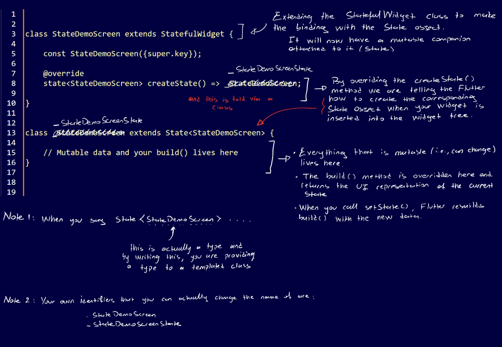

Note that when overriding `build()` for Stateful widgets, you can return `MaterialApp`, BUT you should not do so (except in very specific cases).

The `MaterialApp` is the root widget of most Flutter apps. It sets up:

- Global app-level settings
- The app-wide `Navigator` and `ScaffoldMessenger`
- Default material design behavior

So usually, the `MaterialApp` lives only once, right in your `main()`.

Returning the `MaterialApp` in your StetfulWidget extension means that everytime you call `setState()`, `MaterialApp` rebuilds.

- Rebuilding a `MaterialApp` means reinitializing routing, themes, navigation stack- all expensive operations.

Hence:

> The root `MaterialApp` should be devlared once and your screen widgets (Stateful or Stateless) shoudl return Scaffold or lower-level layout widgets instead.

**Return the `MaterialApp` from the top-level app widget's `build()`- the one you pass to `runApp(...)`**

```
raw
```

You never call `createState()` yourself, you just override it.

- `createState()` is a framework-level hook that Flutter itself calls excatlly once, when it first inserts your `StatefulWidget` into the widget tree.

```
raw
```

On the other hand, you call `setState()` manually when your state's data changes.

- It's like telling Flutter something changed- please rebuild my UI.

You use `setState()` by:

1. Calling it in your change function
2. And you define your change operation as an anonymous callback function for the `setState()` function's parameter:

```
void yourChangeFunction(){
    setState(() {
    // your mutable variables change here
    });
}
```

```
raw
```

Full exmaple:

```
class _CounterScreenState extends State<CounterScreen> {
  int _count = 0; // state variable

  void _increment() {
    setState(() {
      _count++; // change the state here
    });
  }

  @override
  Widget build(BuildContext context) {
    return Scaffold(
      body: Center(child: Text('Count: $_count')),
      floatingActionButton: FloatingActionButton(
        onPressed: _increment, // triggers setState()
        child: const Icon(Icons.add),
      ),
    );
  }
}
```

Notice that we are making our change function, as well as the State class of the widget privete (`_`):

- This is so that no other code outside the file should directly mess with how this screen's state is managed.
- This keeps your widget self-contained and avoids accidental misuse.

```
raw
```

Now you know everyhting, here is an implementation example for a simple counter app:

```
class DynamicCounter extends StatefulWidget {

  const DynamicCounter({super.key});

  @override
  State<DynamicCounter> createState() => _StateDynamicCounter();
}

class _StateDynamicCounter extends State<DynamicCounter> {

  int _count = 0;

  _increment() {
    setState(
        (){
          _count++;
        }
    );
  }

  @override
  Widget build(BuildContext context){
    return Scaffold(
      appBar: AppBar(
        title : Text("CounterApp")
      ),
      floatingActionButton: FloatingActionButton(onPressed: _increment, // <== Note that you have to pass a function reference. If you pass _increment(), the functionality won't work as intended
      child: Text("+")),
      body: Center(child: Text("Counter: $_count"),),
    );
  }

}
```

## Widget Navigation

In a aoo with multiple screens, each unique screen is typically its own top level widget.

For instance, each class that you extend as widget is a screen:

```
class Thrivetrack extends StatelessWidget { // <== This would represent a single screen

  @override
  Widget build(BuildContext context){
    return MaterialApp(
      home : Scaffold(
        appBar: AppBar(
          title: Text("ThriveTrack"),
          backgroundColor: Colors.blueAccent
        ),
        body : Center(child: Column(
          mainAxisAlignment: MainAxisAlignment.center,
          crossAxisAlignment: CrossAxisAlignment.center,
          children: [
            Text("Health is a complete harmony of the body, mind, and spirit"),
            ElevatedButton(onPressed: () => print("Starting the application..."), child: Text("Get Started"))
          ],
        ))
      )
    );


  }
}
```

And when you have multiple of such classes (i.e., screens) in your application and you need a way to navigate between them.

This is where the Navigattor class of Flutter comes into picture.

Apps often have multiple screens- like a home page and a details page.

Flutter uses the **Navigator** class to manage this, which acts like a stack-based controller that manages which screen (called a route) is currently visible.

The **Navigator** internally manages a stack of routes

- Since its a stack structure --> LIFO (Last in First Out)
- New screens are added (pushed) to the top, and screens are removed (popped) from the top. So the last opened screen is the first one to be closed.
- Only the topmost element on the stack (which is the current screen) is accessible to the user.
  - Example: Tapping a grocery item **pushes** the `GroceryItemScreen` onto the stack's top. When the user navigates back, that screen is **popped** off the stack.

Two core operations for any stack can also be seen in the **Navigator** which are:

- Push --> Add (navigate to) a new screen on top of the stack
  - When you call `Navigator.push`, Flutter:
  1. Creates a new Route (e.g., a new page)
  2. Pushes it on top of the stack
  3. Displays it
- Pop --> Remove (go back from) the current screen
  - When you call `Navigator.pop`, Flutter:
    1. Removes (pops) the topmost route
    2. Returns to the previous one

```
raw
```

**`Navigator.push()`**

```
Navigator.push<T>(
  BuildContext context,
  Route<T> route,
)
```

- `Navigator.push()` requires two parameters:
  - `context` --> the current context (where you are now)
  - `route` --> the route to push (i.e., the page that you want to go to), typically created with `MaterialPageRoute`

    ```
    MaterialPageRoute<T>({
        required WidgetBuilder builder, // <== This will be our main focus
        RouteSettings? settings,
        bool maintainState = true,
        bool fullscreenDialog = false,
    })
    ```

    - `builder` --> This is the function taht builds the widget for the route (the new screen to be displayed)
      - Typically used in the following manner:

        ```
        builder : (contex) => SecondScreen(),
        ```

      - `context` --> It's a `BuildContext` object
        - Retains the information regarding the widget's location in the widget tree.
        - You cannot pass anything else.
      - `SecondScreen()` --> The widget instance returned by the builder, representing the screen you want to show. This is basically your class where your widget tree for the page is located (e.g., `class LandingPage extends StatelessWidget {...}`)

```
raw
```

**`Navigator.pop()`**

```
Navigator.pop(context)
```

- `context` --> a fixed argument that cannot be changed
  - retains the information regarding the widget's location in the widget tree.

Very simple to use, it is used to remove the current route from the navigation stack and return to the previous screen. This is how you "go back".

```
raw
```

A route is essentially a screen or page in Flutter. When you navigate between screens, you are actually pushing routes on or off a stack.

So every time you navigate between pages, you're actually manipulating routes.

There are two main ways to define routes:

1. Implicit Routes
   - You create the route directly when navigating
   - For instance:

     ```
     Navigator.push(
         context,
         MaterialPageRoute(builder: (context) => const DetailsScreen()),
     );
     ```

     - This is called implicit because you're not naming or registering the route beforehand

   ```
   raw
   ```

2. Explicit Routes
   - You define the routes explicitly inside your `MaterialApp` using the `routes` prameter of it.
   - This approach is scalable for large apps

   ```
   MaterialApp(
   routes: {
       '/home': (context) => const HomeScreen(),
       '/details': (context) => const DetailsScreen(),
   },
   );
   ```

Implicit routes are straightforward, for instance when a certain button is pressed, you just use `Navigator.push()` or `Navigator.pop()` in the `onPressed` function. And it is as simple as that.

Let's talk a bit more on Explicit Routes though:  
In the `MaterialApp` class, the `routes` parameter is defined as such:

```
MaterialApp{
    //...
    final Map<String, WidgetBuilder> routes;
}
```

- So the `routes` parametes expects a map (dictionary) where:
  - Each key is a `String` that retains the route name
  - Each value is a function (`WidgetBuilder`) that returns a Widget (the screen to display).
- Also note that hierarchical path-like format is used, hence the `/`

```
raw
```

**`Navigator.popUntil()`**

`Navigator.popUntil` removes (pops) screens from the top of the stack until it reaches the specified route.

It only goes back; it does not add any new screen.

The genneral sytanx is as follows:

```
Navigator.popUntil(
  BuildContext context,
  RoutePredicate predicate,
);
```

`context` --> again a fixed parameter, cannot be changed, which retains the information about the location of the widget within the widget tree.

- `predicate` --> A function that takes a `Route` objetc and returns a `bool`. It decides which route to stop at.
  - Flutter will call this function once for each route in the stack, starting from the top.
  - It keeps popping routes until the predicate returns `true`
  - When the predicate returns true, Flutter stops popping- and that route becomes the current screen.
  - `ModalRoute.withName(routePath)` is commonly used as this parameter:

    ```
    ModalRoute.withName(routePath)
    ```

    - `routePath` --> a string representing the named route you defined in your `MaterialApp.route`, for instance `'/homeScreen'`

```
raw
```

Example:

```
Navigator.popUntil(context, ModalRoute.withName('/home'));
```

**`Navigator.pushAndRemoveUntil()`**

It **pushes a new screen** and then removes previous screens from the navigation stack unitl a predicate returns `true`. So:

- It **adds** a screen
- And then **deletes some or all** screens behind it

Esenntially the same logic with `Navigator.popUntil()` with the main difference being it pushes a route on top of the stack.

The general sytnax is as follows:

```
Navigator.pushAndRemoveUntil(
  BuildContext context,
  Route newRoute,
  RoutePredicate predicate,
);
```

- The only new paramaeter is `newRoute`, the rest of the parameters work and used in the same manner as `Navigator.popUntil()`
  - `newRoute` --> the new screen (route) you want to push
    - Most commonly a `MaterialPageRoute` *(same usage as in `Navigator.push()`)*

```
raw
```

**`initalRoute`**

This property specifies the first route (or screen) that the app should display when it starts.

When the app launches, Flutter looks at the `initalRoute` value and matches it with a route defined in the routes map.

It is part of the `MaterialApp` configuration and overrides the `home:` parameter.

- If `initialRoute` is provided:
  - Flutter ignores the `home:` widget
  - Instead it goes to the route whose name matches `initalRoute` in the `routes:` map.
- If `initialRoute` is not provided:
  - Flutter uses the widget defined in `home:` as the inital route.

```
raw
```

Example use case:

```
MaterialApp(
  initialRoute: '/home',
  routes: {
    '/home': (context) => HomeScreen(),
    '/details': (context) => DetailsScreen(),
    '/settings': (context) => SettingsScreen(),
  },
);
```

❗ Note that `initalRoute` must match a key of the map provided in `routes`.

`initialRoute` allows you to conditionally decide upon which page to be the landing page. For instance:

```
initialRoute: userLoggedIn ? '/dashboard' : '/login'
```